# Introduction into the R sf package

## What is the package about?

sf = simple features or simple features access

**What are simple features?**

- feature = real world *thing* (e.g. tree)
- set of features can form a single feature ( e.g. forest)

**characteristics of features:**

- **geometry** (spatial, dimensions: 2D to 4D)
  - longitude x
  - latitude y
  - altitude z
  - measure m (e.g. time of measurement, error of coordinates)
- **attributes** (non-spatial)

### **simple feature geometry types**

- point
- linestring
- polygon
- multipoint
- multilinestring
- multipolygon
- geometrycollection
- …

## Organisation of sf in R

Package sf represents simple features as native R objects  
(sp: defines new classes)

–> simple data structure (three classes exist: sf, sfc, sfg)

–> attributes and geometry stored in data.frame (geometry in list-column)

–> all functions and methods in sf that operate on spatial data are prefixed by st_

- functionality similar to *sp*
- but no new classes defined, it extends data.frames (**native** classes!)

## Organisation of sf in R

- sf = data.frame containing attributes and feature geometries, it contains sfc:
- sfc = list column with geometries for each feature record, composed of sfg
- sfg = the feature geometry of an individual simple feature

## Potential of sf to replace sp

> sp has so far lacked a complete implementation of simple features
- simpler data structures
- simpler handling of CRS
- ability to return distance or area values with proper units (meter, feet or US feet)
- support for geosphere functions to compute distances or areas for longitude/latitude data

## Get started with sf

```r
#install the package
install.packages("sf", repos="http://cran.rstudio.com/", quiet = TRUE)
#install development versions
library(devtools)
install_github("r-spatial/sf", quiet = TRUE)
library(sf)
```

## Example data: North Carolina counties

```r
#read sf objects with st_read
nc <- st_read(system.file("shape/nc.shp", package = "sf"))
class(nc)
```

```
[1] "sf"         "data.frame"
```

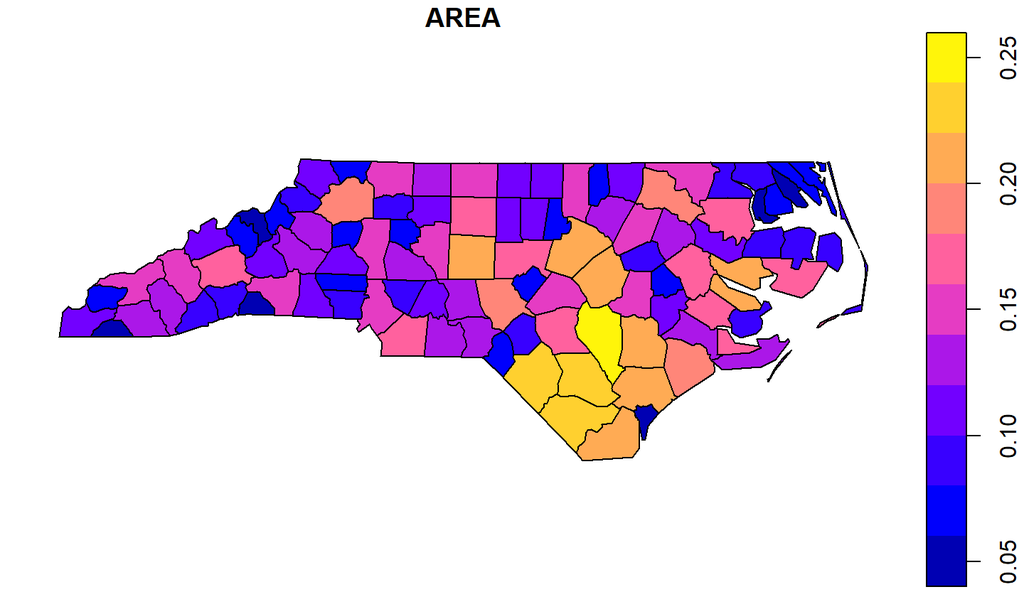

```r
head(nc)
```

```
Simple feature collection with 6 features and 14 fields
geometry type:  MULTIPOLYGON
dimension:      XY
bbox:           xmin: -81.74107 ymin: 36.07282 xmax: -75.77316 ymax: 36.58965
epsg (SRID):    4267
proj4string:    +proj=longlat +datum=NAD27 +no_defs
   AREA PERIMETER CNTY_ CNTY_ID        NAME  FIPS FIPSNO CRESS_ID BIR74
1 0.114     1.442  1825    1825        Ashe 37009  37009        5  1091
2 0.061     1.231  1827    1827   Alleghany 37005  37005        3   487
3 0.143     1.630  1828    1828       Surry 37171  37171       86  3188
4 0.070     2.968  1831    1831   Currituck 37053  37053       27   508
5 0.153     2.206  1832    1832 Northampton 37131  37131       66  1421
6 0.097     1.670  1833    1833    Hertford 37091  37091       46  1452
  SID74 NWBIR74 BIR79 SID79 NWBIR79                       geometry
1     1      10  1364     0      19 MULTIPOLYGON (((-81.4727554...
2     0      10   542     3      12 MULTIPOLYGON (((-81.2398910...
3     5     208  3616     6     260 MULTIPOLYGON (((-80.4563446...
4     1     123   830     2     145 MULTIPOLYGON (((-76.0089721...
5     9    1066  1606     3    1197 MULTIPOLYGON (((-77.2176666...
6     7     954  1838     5    1237 MULTIPOLYGON (((-76.7450637...
```

```r
#access geometry list-column
nc_geom <- st_geometry(nc)

nc_geom [[1]]
```

```
MULTIPOLYGON (((-81.4727554321289 36.2343559265137, -81.5408401489258 36.2725067138672, -81.5619812011719 36.2735939025879, -81.6330642700195 36.3406867980957, -81.7410736083984 36.3917846679688, -81.6982803344727 36.4717788696289, -81.7027969360352 36.5193405151367, -81.6699981689453 36.58964920043…
```

*sfc* object: simple feature geometry list-column  
*sfg* object: simple feature geometry –> geometry for a single feature

```r
#attributes of sfc
attributes(nc_geom)
```

```
$n_empty
[1] 0

$crs
Coordinate Reference System:
  EPSG: 4267
  proj4string: "+proj=longlat +datum=NAD27 +no_defs"

$class
[1] "sfc_MULTIPOLYGON" "sfc"

$precision
[1] 0

$bbox
     xmin      ymin      xmax      ymax
-84.32385  33.88199 -75.45698  36.58965
```

## Some useful commands

```r
#methods of sf objects
methods(class = "sf")
```

```
 [1] $<-                   [                     [[<-
 [4] aggregate             cbind                 coerce
 [7] initialize            merge                 plot
[10] print                 rbind                 show
[13] slotsFromS3           st_agr                st_agr<-
[16] st_as_sf              st_bbox               st_boundary
[19] st_buffer             st_cast               st_centroid
[22] st_collection_extract st_convex_hull        st_coordinates
[25] st_crs                st_crs<-              st_difference
[28] st_geometry           st_geometry<-         st_intersection
[31] st_is                 st_line_merge         st_node
[34] st_point_on_surface   st_polygonize         st_precision
[37] st_segmentize         st_set_precision      st_simplify
[40] st_snap               st_sym_difference     st_transform
[43] st_triangulate        st_union              st_voronoi
[46] st_wrap_dateline      st_write              st_zm
see '?methods' for accessing help and source code
```

```r
#methods for geometry list-columns (sfc)
methods(class = "sfc")
```

```
 [1] [                     [<-                   as.data.frame
 [4] c                     coerce                format
 [7] initialize            Ops                   print
[10] rep                   show                  slotsFromS3
[13] st_as_binary          st_as_text            st_bbox
[16] st_boundary           st_buffer             st_cast
[19] st_centroid           st_collection_extract st_convex_hull
[22] st_coordinates        st_crs                st_crs<-
[25] st_difference         st_geometry           st_intersection
[28] st_is                 st_line_merge         st_node
[31] st_point_on_surface   st_polygonize         st_precision
[34] st_segmentize         st_set_precision      st_simplify
[37] st_snap               st_sym_difference     st_transform
[40] st_triangulate        st_union              st_voronoi
[43] st_wrap_dateline      st_write              st_zm
[46] str                   summary
see '?methods' for accessing help and source code
```

```r
#convert sf object to data.frame
nc.no_sf <- as.data.frame(nc)
class(nc.no_sf)
```

```
[1] "data.frame"
```

## Creating some sf objects

```r
## MULTIPOINT
p <- rbind(c(3.2,4), c(3,4.6), c(3.8,4.4), c(3.5,3.8), c(3.4,3.6), c(3.9,4.5))
(mp <- st_multipoint(p))
```

```
MULTIPOINT (3.2 4, 3 4.6, 3.8 4.4, 3.5 3.8, 3.4 3.6, 3.9 4.5)
```

```r
## LINESTRING
s1 <- rbind(c(0,3),c(0,4),c(1,5),c(2,5))
(ls <- st_linestring(s1))
```

```
LINESTRING (0 3, 0 4, 1 5, 2 5)
```

```r
## MULTILINESTRING
s2 <- rbind(c(0.2,3), c(0.2,4), c(1,4.8), c(2,4.8))
s3 <- rbind(c(0,4.4), c(0.6,5))
(mls <- st_multilinestring(list(s1,s2,s3)))
```

```
MULTILINESTRING ((0 3, 0 4, 1 5, 2 5), (0.2 3, 0.2 4, 1 4.8, 2 4.8), (0 4.4, 0.6 5))
```

## Creating some sf objects

```r
## MULTIPOLYGON
p1 <- rbind(c(0,0), c(1,0), c(3,2), c(2,4), c(1,4), c(0,0))
p2 <- rbind(c(1,1), c(1,2), c(2,2), c(1,1))
pol <-st_polygon(list(p1,p2))
p3 <- rbind(c(3,0), c(4,0), c(4,1), c(3,1), c(3,0))
p4 <- rbind(c(3.3,0.3), c(3.8,0.3), c(3.8,0.8), c(3.3,0.8), c(3.3,0.3))[5:1,]
p5 <- rbind(c(3,3), c(4,2), c(4,3), c(3,3))
(mpol <- st_multipolygon(list(list(p1,p2), list(p3,p4), list(p5))))
```

```
MULTIPOLYGON (((0 0, 1 0, 3 2, 2 4, 1 4, 0 0), (1 1, 1 2, 2 2, 1 1)), ((3 0, 4 0, 4 1, 3 1, 3 0), (3.3 0.3, 3.3 0.8, 3.8 0.8, 3.8 0.3, 3.3 0.3)), ((3 3, 4 2, 4 3, 3 3)))
```

```r
## GEOMETRYCOLLECTION
(gc <- st_geometrycollection(list(mp, mpol, ls)))
```

```
GEOMETRYCOLLECTION (MULTIPOINT (3.2 4, 3 4.6, 3.8 4.4, 3.5 3.8, 3.4 3.6, 3.9 4.5), MULTIPOLYGON (((0 0, 1 0, 3 2, 2 4, 1 4, 0 0), (1 1, 1 2, 2 2, 1 1)), ((3 0, 4 0, 4 1, 3 1, 3 0), (3.3 0.3, 3.3 0.8, 3.8 0.8, 3.8 0.3, 3.3 0.3)), ((3 3, 4 2, 4 3, 3 3))), LINESTRING (0 3, 0 4, 1 5, 2 5))
```

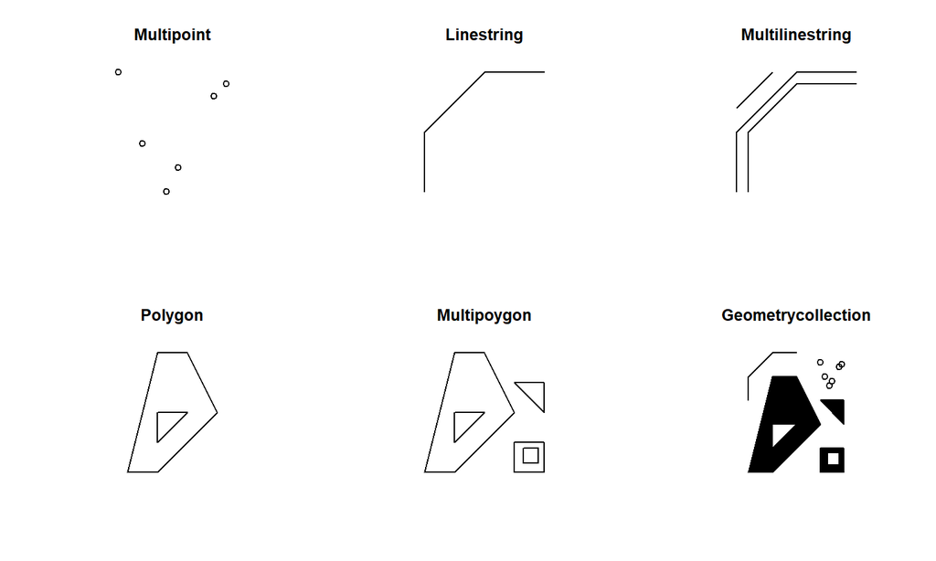

```r
par(mfrow = c(2,3))
plot(mp, main = "Multipoint"); plot(ls, main = "Linestring"); plot(mls, main =
"Multilinestring"); plot(pol, main = "Polygon"); plot(mpol, main = "Multipoygon");
plot(gc, main = "Geometrycollection")
```

## Reading and writing

```r
#read sf object with st_read
filename <-  system.file("shape/nc.shp", package = "sf") #ESRI Shapefile
file <- st_read(filename, quiet = TRUE)

#write file with st_write
st_write(nc, "nc.shp", driver = "ESRI Shapefile")
```

```
Writing layer `nc' to data source `nc.shp' using driver `ESRI Shapefile'
features:       100
fields:         14
geometry type:  Multi Polygon
```

–> multiple formats possible (also lists with several layers)  
–> reading and writing directly from and to spatial databases possible

## Manipulating simple features geometries

## Type transformations

st_cast:  
- single geometries into multi-geometries or vice versa  
- geometrycollection into its component (if length = 1)

```r
p = st_polygon(list(rbind(c(-1,-1), c(1,-1), c(1,1), c(-1,1), c(-1,-1))))
class(p)
```

```
[1] "XY"      "POLYGON" "sfg"
```

```r
p_multi <- st_cast(p, "MULTIPOLYGON")
class(p_multi)
```

```
[1] "XY"           "MULTIPOLYGON" "sfg"
```

## Affine transformations

f(x) = xA + b –> flatten, scale, rotate and translate

```r
#rotate 90% clockwise around centroid
#shrink to 75% of their originial size
cntrd = st_centroid(nc_geom)
rot = function(a) matrix(c(cos(a), sin(a), -sin(a), cos(a)),2,2)
nc_geom2 = (nc_geom - cntrd) *rot(pi/2)* .75 + cntrd
```

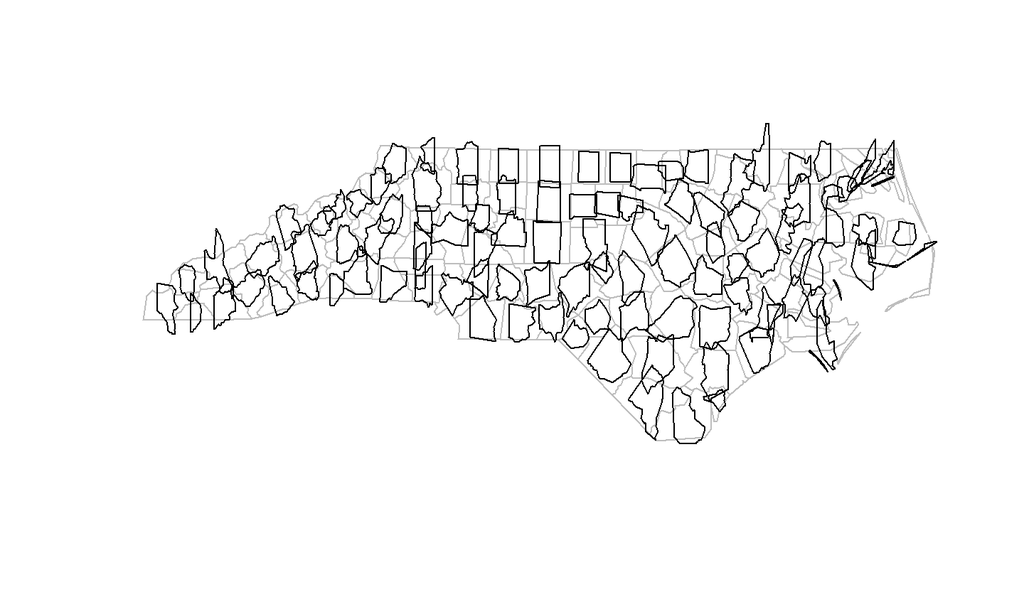

## Transformations and conversions

```r
#CRS transformation
nc.web_mercator <- st_transform(nc, 3857)
st_crs(nc.web_mercator)
```

```
Coordinate Reference System:
  EPSG: 3857
  proj4string: "+proj=merc +a=6378137 +b=6378137 +lat_ts=0.0 +lon_0=0.0 +x_0=0.0 +y_0=0 +k=1.0 +units=m +nadgrids=@null +wktext +no_defs"
```

```r
#Conversion from/to sp object
nc.sp <- as(nc, "Spatial")
class(nc.sp)
```

```
[1] "SpatialPolygonsDataFrame"
attr(,"package")
[1] "sp"
```

```r
nc.sf <- as(nc.sp, "sf")
class(nc.sf)
```

```
[1] "sf"         "data.frame"
```

## Geometrical operations

```r
#creating geometry set 1 with three polygons
b0 = st_polygon(list(rbind(c(-1,-1), c(1,-1), c(1,1), c(-1,1), c(-1,-1))))
b1 = b0 + 2
b2 = b0 + c(-0.2, 2)
x = st_sfc(b0, b1, b2)
#creating geometry set 2 with four polygons
a0 = b0 * 0.8
a1 = a0 * 0.5 + c(2, 0.7)
a2 = a0 + 1
a3 = b0 * 0.5 + c(2, -0.5)
y = st_sfc(a0,a1,a2,a3)
```

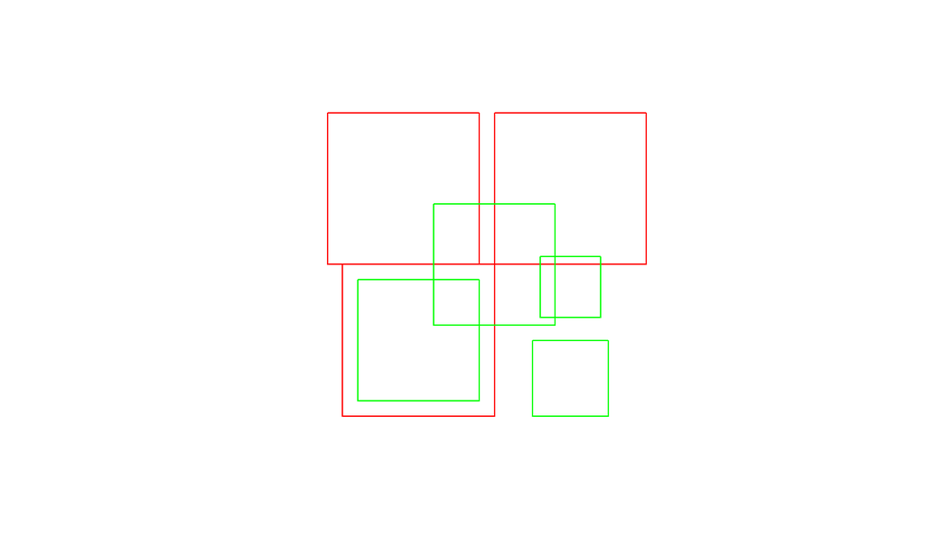

## Measuring

```r
#area of polygons
st_area(x)
```

```
[1] 4 4 4
```

```r
#length of geometries
st_length(st_sfc(st_linestring(rbind(c(0,0), c(1,1), c(1,2))), st_linestring
                 (rbind(c(0,0), c(1,0)))))
```

```
[1] 2.414214 1.000000
```

```r
#shortest distance matrix between geometries
st_distance(x,y)
```

```
          [,1] [,2] [,3]     [,4]
[1,] 0.0000000  0.6    0 0.500000
[2,] 0.2828427  0.0    0 1.000000
[3,] 0.2000000  0.8    0 1.220656
```

## Test topology

```r
#check if geometries are topologically valid
b1 = st_polygon(list(rbind(c(-1,-1), c(1,-1), c(1,1), c(0,-1), c(-1,-1))))
```

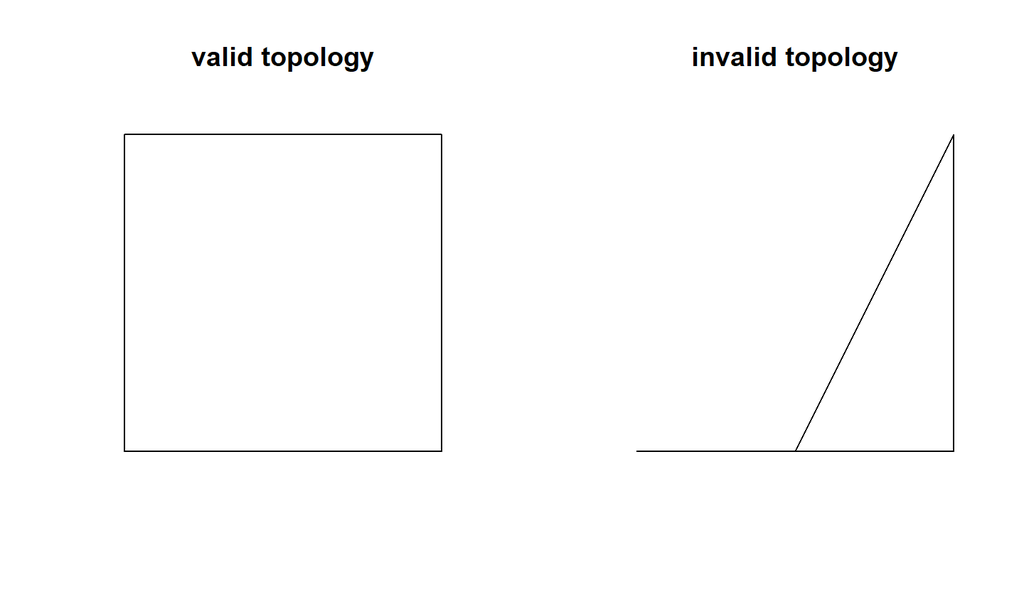

```r
st_is_valid(st_sfc(b0, b1))
```

```
[1]  TRUE FALSE
```

```r
#intersection between objects
st_intersects(x,y)
```

```
Sparse geometry binary predicate list of length 3, where the predicate was `intersects'
 1: 1, 3
 2: 2, 3
 3: 3
```

```r
st_intersects(x,y, sparse = FALSE)
```

```
      [,1]  [,2] [,3]  [,4]
[1,]  TRUE FALSE TRUE FALSE
[2,] FALSE  TRUE TRUE FALSE
[3,] FALSE FALSE TRUE FALSE
```

### other operations:

- st_disjoint
- st_touches
- st_crosses
- st_within
- st_contains
- st_overlaps
- st_covers
- st_subdivide # can be used to reduce computing time (see references^4)
- …

## Return new geometries

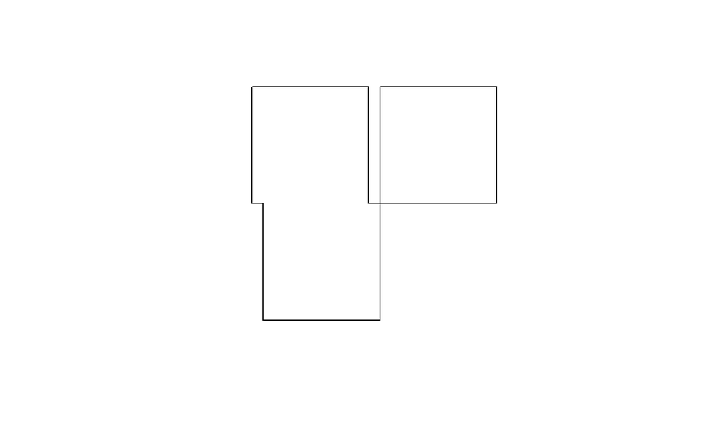

```r
#union objects
u = st_union(x)
plot(u)
```

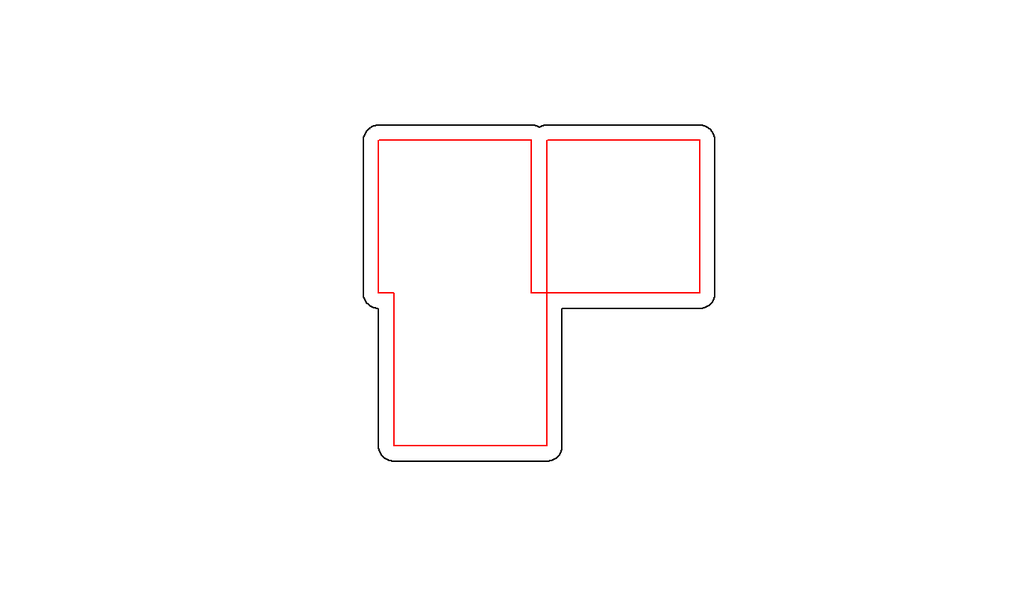

```r
#buffer objects
plot(st_buffer(u, 0.2)); plot(u, border = "red", add = TRUE)
```

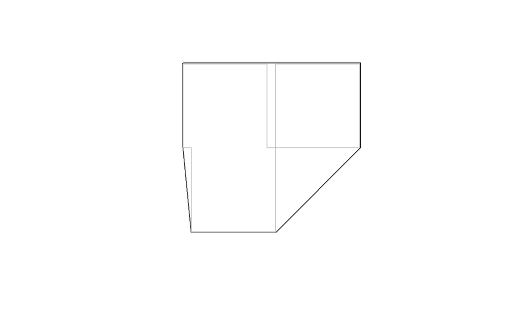

```r
plot(st_convex_hull(u)); plot(u*0.99, border = "grey", add = TRUE)
```

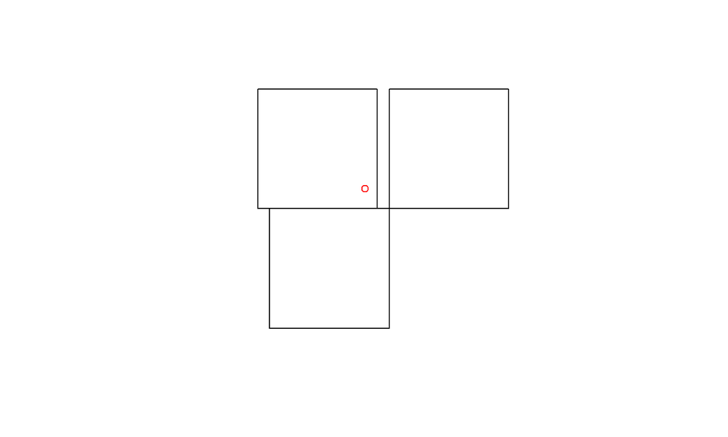

```r
plot(x); plot(st_centroid(u), col = "red",  add = TRUE)
```

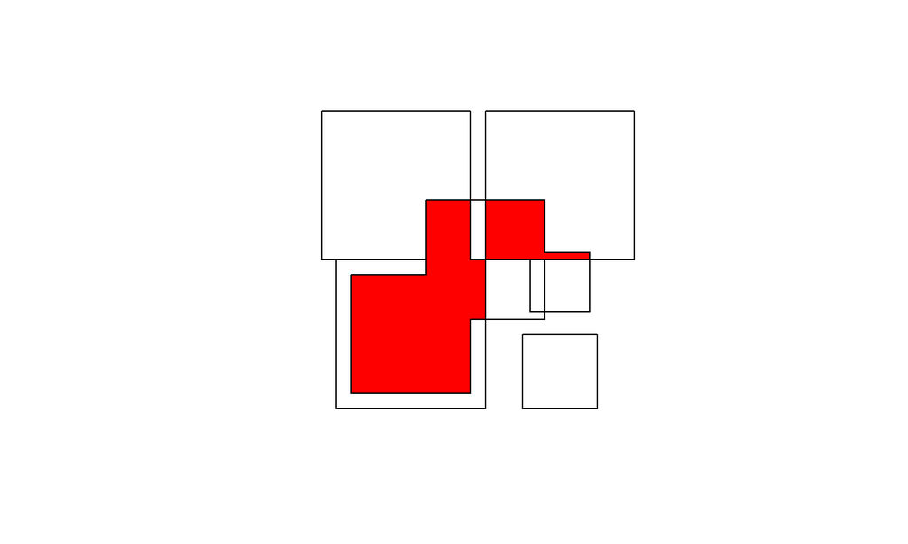

```r
plot(x); plot(y, add = TRUE);plot(st_intersection(st_union(x), st_union(y)),
                                  add = TRUE, col = "red")
```

### other operations

- st_difference
- st_segmentize
- st_polygonize
- …

## Manipulating simple features

## 1 dplyr package - basics

```r
library(dplyr)
```

## 1 dplyr package - basics - grammar

```r
nc %>% select(NWBIR74) %>% head(2)
```

```
Simple feature collection with 2 features and 1 field
geometry type:  MULTIPOLYGON
dimension:      XY
bbox:           xmin: -81.74107 ymin: 36.23436 xmax: -80.90344 ymax: 36.58965
epsg (SRID):    4267
proj4string:    +proj=longlat +datum=NAD27 +no_defs
  NWBIR74                       geometry
1      10 MULTIPOLYGON (((-81.4727554...
2      10 MULTIPOLYGON (((-81.2398910...
```

```r
nc %>% as.data.frame %>% select(NWBIR74) %>% head(2) # drop geometry
```

```
  NWBIR74
1      10
2      10
```

## 2 Subset

```r
# subsetting feature sets using [] (... or dplyr)
nc[1,"NWBIR74"] # Alternative: nc[1,11]
```

```
Simple feature collection with 1 feature and 1 field
geometry type:  MULTIPOLYGON
dimension:      XY
bbox:           xmin: -81.74107 ymin: 36.23436 xmax: -81.23989 ymax: 36.58965
epsg (SRID):    4267
proj4string:    +proj=longlat +datum=NAD27 +no_defs
  NWBIR74                       geometry
1      10 MULTIPOLYGON (((-81.4727554...
```

```r
nc[1, "NWBIR74", drop = TRUE] # drop geometry
```

```
[1] 10
attr(,"class")
[1] "numeric"
```

## 2 Subset geometry + attribute

```r
Ashe = nc[nc$NAME == "Ashe",]
class(Ashe)
```

```
[1] "sf"         "data.frame"
```

## 2 Subset geometry + attribute

```r
nc[Ashe,]
```

```
although coordinates are longitude/latitude, st_intersects assumes that they are planar
```

```
Simple feature collection with 4 features and 14 fields
geometry type:  MULTIPOLYGON
dimension:      XY
bbox:           xmin: -81.91116 ymin: 35.98933 xmax: -80.87086 ymax: 36.58965
epsg (SRID):    4267
proj4string:    +proj=longlat +datum=NAD27 +no_defs
    AREA PERIMETER CNTY_ CNTY_ID      NAME  FIPS FIPSNO CRESS_ID BIR74
1  0.114     1.442  1825    1825      Ashe 37009  37009        5  1091
2  0.061     1.231  1827    1827 Alleghany 37005  37005        3   487
18 0.199     1.984  1874    1874    Wilkes 37193  37193       97  3146
19 0.081     1.288  1880    1880   Watauga 37189  37189       95  1323
   SID74 NWBIR74 BIR79 SID79 NWBIR79                       geometry
1      1      10  1364     0      19 MULTIPOLYGON (((-81.4727554...
2      0      10   542     3      12 MULTIPOLYGON (((-81.2398910...
18     4     200  3725     7     222 MULTIPOLYGON (((-81.0205688...
19     1      17  1775     1      33 MULTIPOLYGON (((-81.8062210...
```

```r
nc[Ashe, op = st_touches]
```

```
although coordinates are longitude/latitude, st_touches assumes that they are planar
```

```
Simple feature collection with 3 features and 14 fields
geometry type:  MULTIPOLYGON
dimension:      XY
bbox:           xmin: -81.91116 ymin: 35.98933 xmax: -80.87086 ymax: 36.57286
epsg (SRID):    4267
proj4string:    +proj=longlat +datum=NAD27 +no_defs
    AREA PERIMETER CNTY_ CNTY_ID      NAME  FIPS FIPSNO CRESS_ID BIR74
2  0.061     1.231  1827    1827 Alleghany 37005  37005        3   487
18 0.199     1.984  1874    1874    Wilkes 37193  37193       97  3146
19 0.081     1.288  1880    1880   Watauga 37189  37189       95  1323
   SID74 NWBIR74 BIR79 SID79 NWBIR79                       geometry
2      0      10   542     3      12 MULTIPOLYGON (((-81.2398910...
18     4     200  3725     7     222 MULTIPOLYGON (((-81.0205688...
19     1      17  1775     1      33 MULTIPOLYGON (((-81.8062210...
```

```r
nc %>% filter(lengths(st_touches(., Ashe)) > 0)
```

```
although coordinates are longitude/latitude, st_touches assumes that they are planar
```

```
Simple feature collection with 3 features and 14 fields
geometry type:  MULTIPOLYGON
dimension:      XY
bbox:           xmin: -81.91116 ymin: 35.98933 xmax: -80.87086 ymax: 36.57286
epsg (SRID):    4267
proj4string:    +proj=longlat +datum=NAD27 +no_defs
   AREA PERIMETER CNTY_ CNTY_ID      NAME  FIPS FIPSNO CRESS_ID BIR74
1 0.061     1.231  1827    1827 Alleghany 37005  37005        3   487
2 0.199     1.984  1874    1874    Wilkes 37193  37193       97  3146
3 0.081     1.288  1880    1880   Watauga 37189  37189       95  1323
  SID74 NWBIR74 BIR79 SID79 NWBIR79                       geometry
1     0      10   542     3      12 MULTIPOLYGON (((-81.2398910...
2     4     200  3725     7     222 MULTIPOLYGON (((-81.0205688...
3     1      17  1775     1      33 MULTIPOLYGON (((-81.8062210...
```

## 2 Subset geometry + attribute

```
although coordinates are longitude/latitude, st_touches assumes that they are planar
```

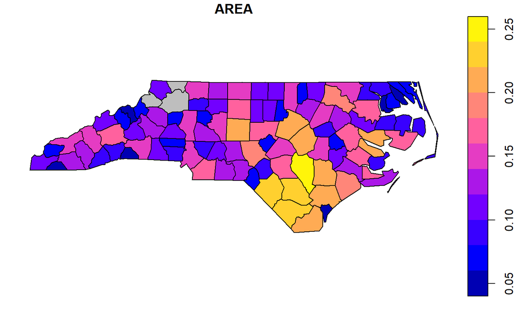

```r
# See effect of (two) coding alternatives above:
plot(nc[1])
plot(nc[Ashe, op = st_touches], col = 'grey', add = TRUE)
```

## 3 Aggregate

```r
# aggregating feature sets using aggregate()
# Task: Compare the fraction of SID of 1974 of the counties that intersect with Ashe
# to the remaining ones?
nc <- nc %>% mutate(frac74 = SID74 / BIR74)
(a <- aggregate(nc[,"frac74"], list(Ashe_nb = lengths(st_intersects(nc, Ashe)) > 0), mean))
```

```
although coordinates are longitude/latitude, st_intersects assumes that they are planar
```

```
Simple feature collection with 2 features and 2 fields
Attribute-geometry relationship: 0 constant, 1 aggregate, 1 identity
geometry type:  GEOMETRY
dimension:      XY
bbox:           xmin: -84.32385 ymin: 33.88199 xmax: -75.45698 ymax: 36.58965
epsg (SRID):    4267
proj4string:    +proj=longlat +datum=NAD27 +no_defs
  Ashe_nb      frac74                       geometry
1   FALSE 0.002100164 MULTIPOLYGON (((-76.5442733...
2    TRUE 0.000735976 POLYGON ((-81.0205688476562...
```

```r
list(Ashe_nb = lengths(st_intersects(nc, Ashe)) > 0)
```

```
although coordinates are longitude/latitude, st_intersects assumes that they are planar
```

```
$Ashe_nb
  [1]  TRUE  TRUE FALSE FALSE FALSE FALSE FALSE FALSE FALSE FALSE FALSE
 [12] FALSE FALSE FALSE FALSE FALSE FALSE  TRUE  TRUE FALSE FALSE FALSE
 [23] FALSE FALSE FALSE FALSE FALSE FALSE FALSE FALSE FALSE FALSE FALSE
 [34] FALSE FALSE FALSE FALSE FALSE FALSE FALSE FALSE FALSE FALSE FALSE
 [45] FALSE FALSE FALSE FALSE FALSE FALSE FALSE FALSE FALSE FALSE FALSE
 [56] FALSE FALSE FALSE FALSE FALSE FALSE FALSE FALSE FALSE FALSE FALSE
 [67] FALSE FALSE FALSE FALSE FALSE FALSE FALSE FALSE FALSE FALSE FALSE
 [78] FALSE FALSE FALSE FALSE FALSE FALSE FALSE FALSE FALSE FALSE FALSE
 [89] FALSE FALSE FALSE FALSE FALSE FALSE FALSE FALSE FALSE FALSE FALSE
[100] FALSE
```

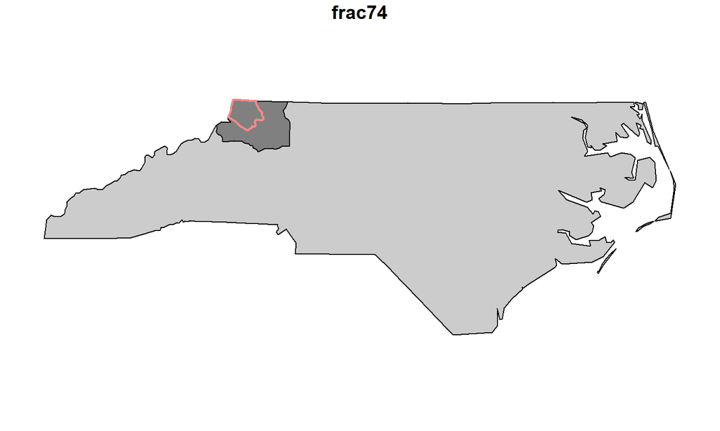

```r
plot(a[2], col = c(grey(.8), grey(.5)))
plot(st_geometry(Ashe), border = '#ff8888', add = TRUE, lwd = 2)
```

## 4 Join

```r
# Joining two feature sets based on attributes or feature geometry (st_join(), merge())

x = st_sf(a = 1:2, geom = st_sfc(st_point(c(0,0)), st_point(c(1,1)))) # create sf points
y = data.frame(a = 2:3) # create data.frame
merge(x, y)
```

```
Simple feature collection with 1 feature and 1 field
geometry type:  POINT
dimension:      XY
bbox:           xmin: 1 ymin: 1 xmax: 1 ymax: 1
epsg (SRID):    NA
proj4string:    NA
  a    geometry
1 2 POINT (1 1)
```

```r
x = st_sf(a = 1:3, geom = st_sfc(st_point(c(1,1)), st_point(c(2,2)), st_point(c(3,3)))) # create three points
y = st_buffer(x, 0.1) # create buffer
st_join(x, y) # first argument delivers the attributes + the geometry
```

```
Simple feature collection with 3 features and 2 fields
geometry type:  POINT
dimension:      XY
bbox:           xmin: 1 ymin: 1 xmax: 3 ymax: 3
epsg (SRID):    NA
proj4string:    NA
  a.x a.y        geom
1   1   1 POINT (1 1)
2   2   2 POINT (2 2)
3   3   3 POINT (3 3)
```

```r
st_join(y, x)
```

```
Simple feature collection with 3 features and 2 fields
geometry type:  POLYGON
dimension:      XY
bbox:           xmin: 0.9 ymin: 0.9 xmax: 3.1 ymax: 3.1
epsg (SRID):    NA
proj4string:    NA
  a.x a.y                           geom
1   1   1 POLYGON ((1.1 1, 1.09986295...
2   2   2 POLYGON ((2.1 2, 2.09986295...
3   3   3 POLYGON ((3.1 3, 3.09986295...
```

```r
st_join(y, x, join = st_covers) # matches for circles covering a point
```

```
Simple feature collection with 3 features and 2 fields
geometry type:  POLYGON
dimension:      XY
bbox:           xmin: 0.9 ymin: 0.9 xmax: 3.1 ymax: 3.1
epsg (SRID):    NA
proj4string:    NA
  a.x a.y                           geom
1   1   1 POLYGON ((1.1 1, 1.09986295...
2   2   2 POLYGON ((2.1 2, 2.09986295...
3   3   3 POLYGON ((3.1 3, 3.09986295...
```

## Plotting methods for sf and sfc objects

## 1 Geometry only: sfc

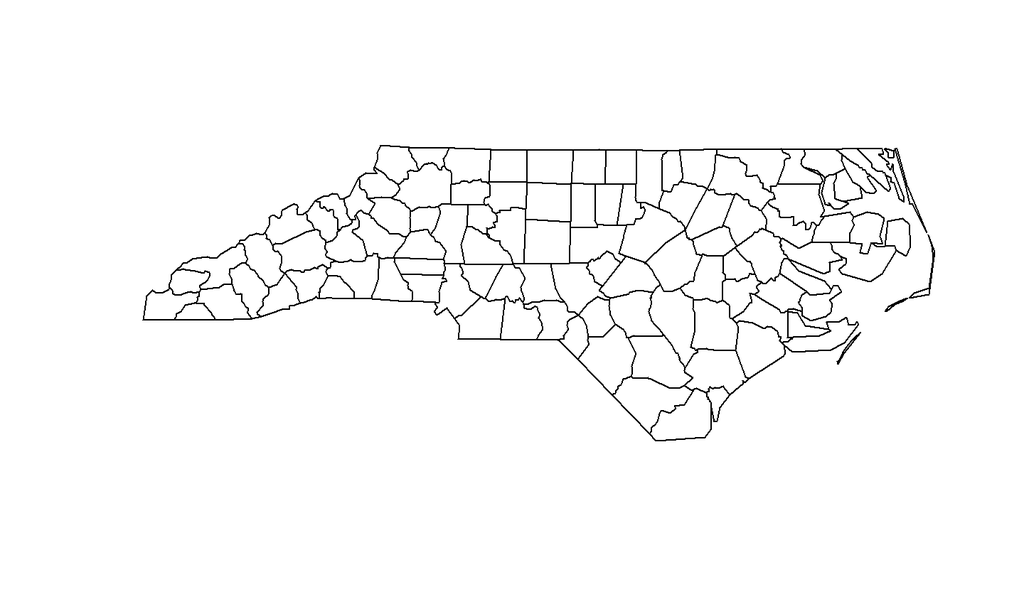

```r
plot(st_geometry(nc))  # basic grammar; can be further annotated with colors, symbols, etc.
```

##

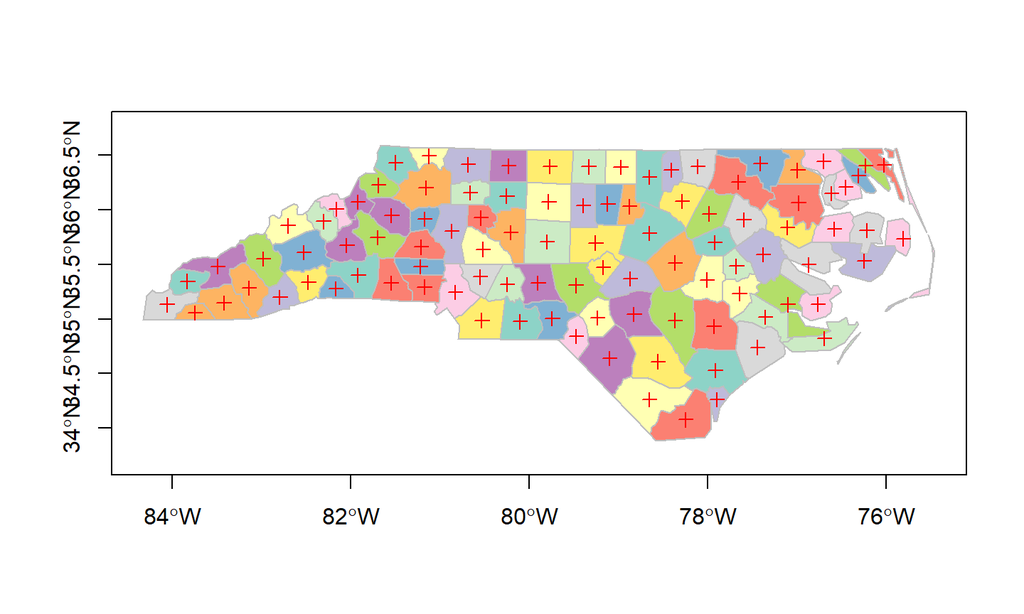

```r
plot(st_geometry(nc), col = sf.colors(12, categorical = TRUE), border = 'grey', axes = TRUE)
plot(st_geometry(st_centroid(nc)), pch = 3, col = 'red', add = TRUE) # adding centroids to plot
```

## 2 Geometry with attributes: sf

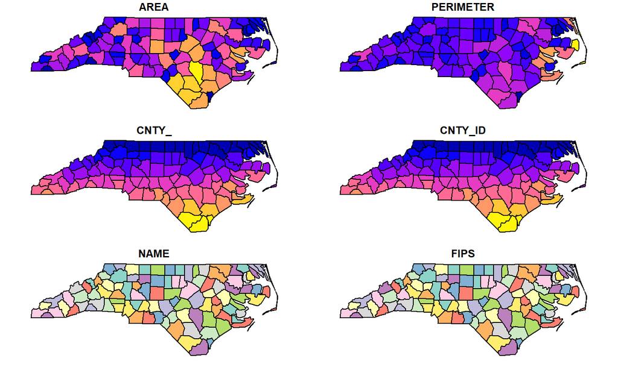

```r
plot(nc, max.plot = 6) # maximum value of max.plot = 14 in this case
```

## Visualisation

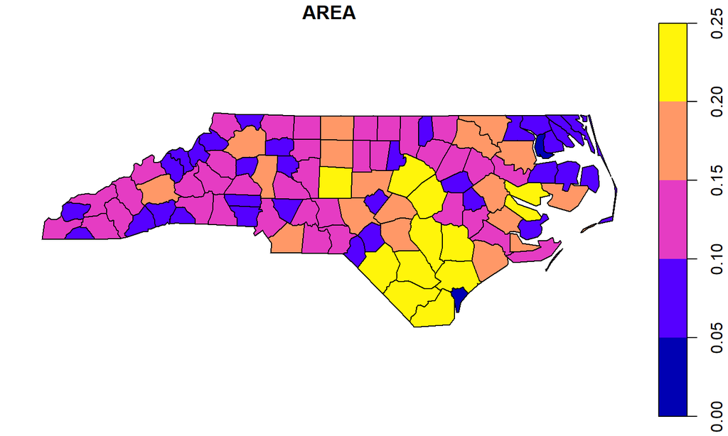

```r
# 1 color keys # default color key is given
# 2 class intervals
plot(nc["AREA"], breaks = c(0,.05,.1,.15,.2,.25))
```

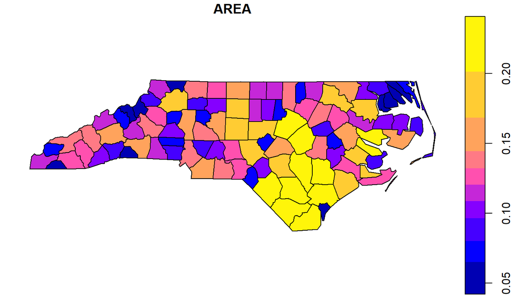

```r
plot(nc["AREA"], breaks = "quantile")
```

```r
# either a numeric vector with the actual breaks, or name of a method accepted by the style argument of classIntervals
```

## Visualisation

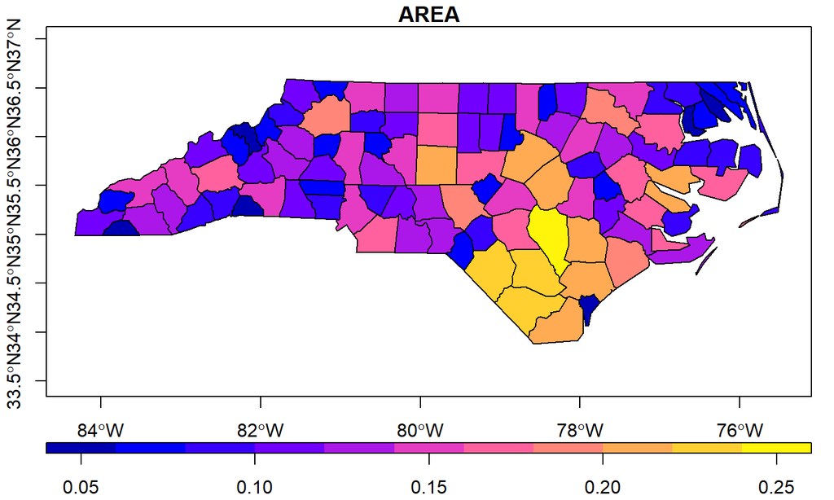

```r
# 3 display axes
plot(nc["AREA"], key.pos = 1, axes = TRUE, key.size = lcm(1.3))
```

```r
# location and size of axes can be defined
```

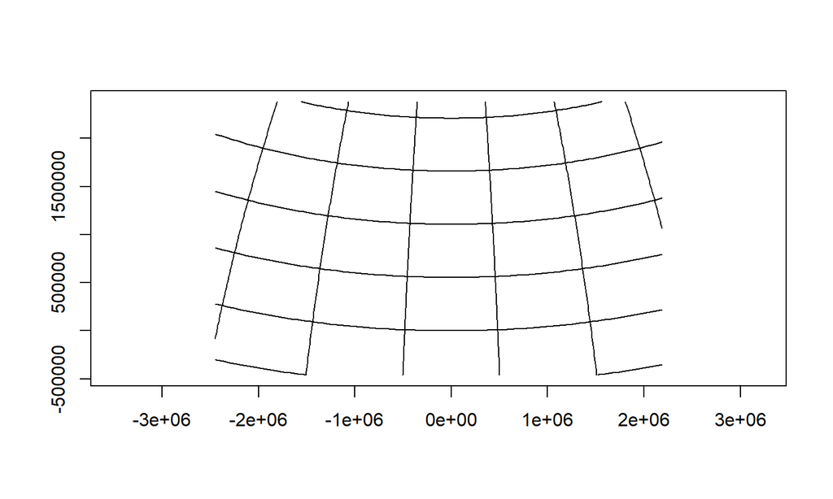

```r
# 4 graticules
library(maps)
usa = st_as_sf(map('usa', plot = FALSE, fill = TRUE))
laea = st_crs("+proj=laea +lat_0=30 +lon_0=-95") # Lambert equal area
usa <- st_transform(usa, laea)
g = st_graticule(usa)
plot(st_geometry(g), axes = TRUE)
```

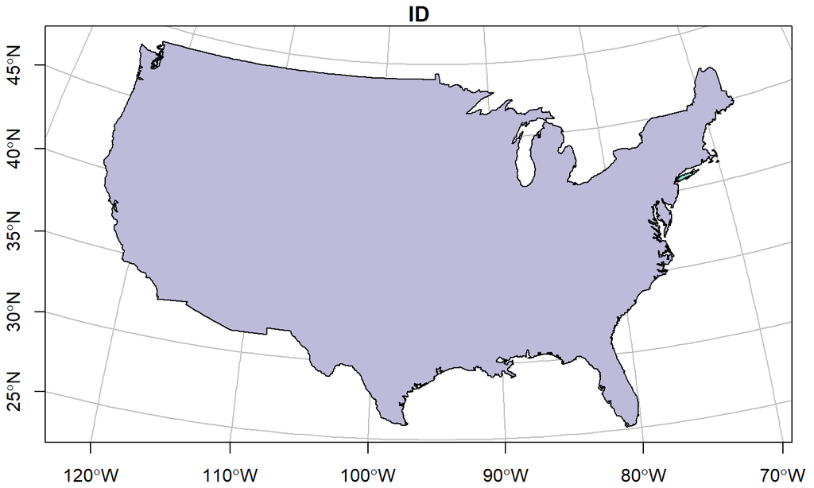

```r
plot(usa, graticule = TRUE, key.pos = NULL, axes = TRUE)
```

## Plotting with other packages

```r
# e.g. ggplot, mapview, tmap, grid
library(rmapshaper) # can be used to simplify your map (reduce drawing time)
# -> Grammar: ms_simplify()

library(mapview)
mapview(nc["BIR74"], col.regions = sf.colors(10))
```

[interactive chart not shown]

## References

- https://github.com/r-spatial/sf
- https://www.r-consortium.org/blog/2017/01/03/simple-features-now-on-cran
- https://seasmith.github.io/blog/simplify_your_map_to_reduce_drawing_time/
- http://www.stevencanplan.com/2017/12/the-genius-of-using-st_subdivide-to-speed-up-postgis-intersection-comparisons/